# Chapter 07: Analysis of Function: Sentence Modes

Sentence Mode and Nuclear PA Phonology without Reg Tier

### Raw Data

Utterance level intonational phonology without Register Tier in M-corpus for all tokens.

| phr_phon | phon_count |
| --- | --- |
| % L*H % | 97 |
| % >H* L*H % | 95 |
| % L*H L*H % | 78 |
| % H* L* L*H % | 58 |
| % H* L*H % | 49 |
| % >H* L*H L% | 29 |
| % L*H L% | 25 |
| % H* !H* L*H % | 22 |
| % H* L*!H L*H % | 21 |
| % H* L*H L% | 20 |
| % H* L*H L*H % | 17 |
| % L*H H% | 13 |
| % H* L*H % | 12 |
| % L*H L*H L% | 10 |
| % >H* L*!H L*H % | 8 |
| % L*H L*!H L*H L% | 6 |
| % >H* L* L*H % | 5 |
| % H* L* L*H L% | 5 |
| %H L*H L*H % | 5 |
| %H L*H % | 5 |
| % H* L*H L% | 5 |
| % L*H L*H H% | 3 |
| % >H* L*H H% | 3 |
| %H L* L*H % | 3 |
| %H L*!H L*H % | 3 |
| %H >H* L*!H L*H % | 3 |
| % L* L*H % | 3 |
| % H* L*H H% | 3 |
| % H* >H* L% | 3 |
| % L*H L% | 3 |
| % L*H % | 2 |
| % H* H* L% | 2 |
| % L*H HL% | 1 |
| % H* L*H HL% | 1 |
| %H H* L* L*H % | 1 |
| % >H* L*H L*H % | 1 |
| % H* L*!H L*H L% | 1 |
| % L*H L* L*H L% | 1 |
| % >H* L* L*H L% | 1 |
| %H >H* L*H % | 1 |
| %H >!H* L*H % | 1 |
| %H H* L*H L*H % | 1 |
| %L H* L*H % | 1 |
| % H* !H*L L*H % | 1 |
| % H* >!H* L*H % | 1 |
| %H !H* L*H % | 1 |
| % H* L*/!H* L*H % | 1 |
| % >H* L*H % | 1 |
| % >H* >H* L% | 1 |
| % >H* L% | 1 |
| % L*H L*H % | 1 |
| % L*H L*H L% | 1 |
| %L H* L*H L% | 1 |
| % L*H L*H L*H % | 1 |
| % >H*> L*H % | 1 |

Utterance level intonational phonology by mode for tokens accounting for at least 1.25% of all tokens.

| # | Phonology | MDC | MWH | MYN | MDQ | total |
| --- | --- | --- | --- | --- | --- | --- |
| 1 | % H* L* L*H % | 5 | 53 | 0 | 0 | 58 |
| 2 | % >H* L*H % | 30 | 0 | 38 | 27 | 95 |
| 3 | % L*H % | 32 | 0 | 37 | 28 | 97 |
| 4 | % H* L*H % | 33 | 0 | 11 | 5 | 49 |
| 5 | % L*H L*H % | 25 | 0 | 29 | 24 | 78 |
| 6 | % H* L*!H L*H % | 0 | 21 | 0 | 0 | 21 |
| 7 | % H* L*H L*H % | 0 | 17 | 0 | 0 | 17 |
| 8 | % H* !H* L*H % | 5 | 17 | 0 | 0 | 22 |
| 9 | % L*H L% | 1 | 0 | 12 | 12 | 25 |
| 10 | % >H* L*H L% | 10 | 0 | 8 | 11 | 29 |
| 11 | % H* L*H L% | 6 | 0 | 4 | 10 | 20 |
| 12 | % L*H H% | 0 | 0 | 4 | 9 | 13 |
| 13 | % >H* L*!H L*H % | 0 | 8 | 0 | 0 | 8 |
| 14 | % H* L*H % | 3 | 8 | 1 | 0 | 12 |
| 15 | % L*H L*H L% | 1 | 0 | 1 | 8 | 10 |

Distibution by speaker of nuclear pitch accents in M-corpus (raw)

| speaker | H* | L*H | >H* |
| --- | --- | --- | --- |
| F5 | 0 | 59 | 0 |
| F6 | 0 | 60 | 0 |
| F12 | 0 | 60 | 0 |
| F15 | 0 | 60 | 0 |
| F16 | 0 | 60 | 0 |
| F17 | 0 | 55 | 0 |
| M4 | 0 | 57 | 0 |
| M5 | 0 | 60 | 0 |
| M8 | 2 | 54 | 5 |
| M9 | 0 | 47 | 0 |
| M10 | 0 | 60 | 0 |
| Total | 2 | 632 | 5 |

#### Adjusted Data (Nuclear Contours and Final Boundaries)

The raw data is unbalanced since there number of utterances per target speaker varies slightly. For some speakers, there are no repetitions of some target utterances. Therefore, the data has been adjusted to project an estimated balanced number of tokens per speaker per target utterance.

Firstly a tibble is created summarising the proportion of pitch accents per mode per speaker. This is done in three initial stages:

1. Count the number of phonological tokens per stimulus per speaker.
2. Convert the counts to proportion per stimulus per speaker.
3. Convert the proportion per stimulus per speaker proportion per stimulus per mode.

From this table to summary tables are created:

1. pitch accents per speaker (adjusted)
   1. Calculate the sum all proproations per token per speaker.
   2. Convert proportions to an integer based on an ideal total number of tokens per speaker.
2. pitch accents per speaker (adjusted):
   1. Calculate the sum all proproations per token per mode.
   2. Convert proportions to an integer based on an ideal total number of tokens per mode
3. pitch accents by gender and mode (adjusted):
   1. Calculate the sum all proproations per token by mode and gender.
   2. Convert proportions to an integer based on an ideal total number of tokens per mode as if there were an equal numnber of male and female participants.

#### Nuclear Pitch Accent by Speaker (adjusted)

Distibution by speaker of nuclear pitch accents in M-corpus (adjusted)

| speaker | H* | L*H | >H* |
| --- | --- | --- | --- |
| F5 | 0 | 60 | 0 |
| F6 | 0 | 60 | 0 |
| F12 | 0 | 60 | 0 |
| F15 | 0 | 60 | 0 |
| F16 | 0 | 60 | 0 |
| F17 | 0 | 60 | 0 |
| M4 | 0 | 60 | 0 |
| M5 | 0 | 60 | 0 |
| M8 | 2 | 54 | 5 |
| M9 | 0 | 60 | 0 |
| M10 | 0 | 60 | 0 |
| Total | 2 | 654 | 5 |

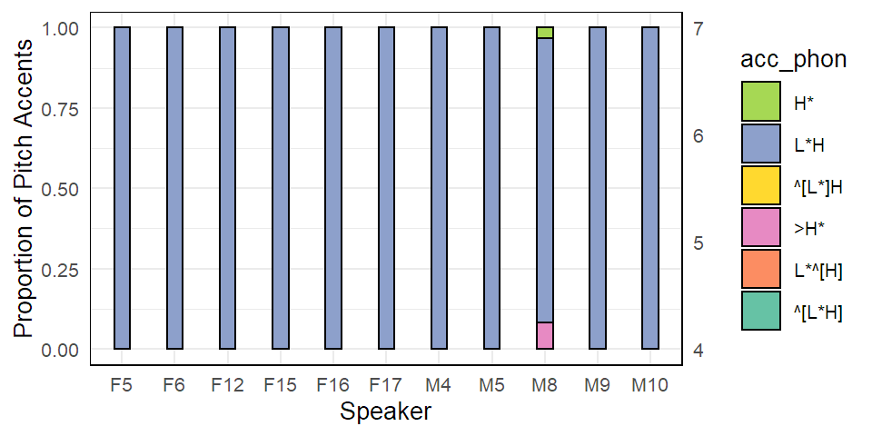

#### Nuclear Pitch Accent by Sentence Mode (adjusted)

Distibution by mode of nuclear pitch accents in M-corpus (adjusted)

| mode | H* | L*H | >H* |
| --- | --- | --- | --- |
| MDC | 2 | 162 | 2 |
| MWH | 0 | 165 | 0 |
| MYN | 0 | 163 | 2 |
| MDQ | 0 | 164 | 1 |
| Total | 2 | 654 | 5 |

It is clear that there is little relationship between the pitch accent and mode when the register tier is discounted. However, looking at the raw data for the phrase-level phonology, it looks like L% boundaries are more commonly associated with questions than declarative.

Therefore, it might be worth looking at the nuclear contour as a whole in this data set.

Distibution by speaker of nuclear contours in M-corpus (adjusted)

| speaker | L*H % | L*H L% | L*H H% | L*H HL% | >H* L% | H* L% |
| --- | --- | --- | --- | --- | --- | --- |
| F5 | 32 | 15 | 7 | 6 | 0 | 0 |
| F6 | 53 | 2 | 3 | 2 | 0 | 0 |
| F12 | 21 | 38 | 1 | 0 | 0 | 0 |
| F15 | 53 | 3 | 4 | 0 | 0 | 0 |
| F16 | 59 | 0 | 1 | 0 | 0 | 0 |
| F17 | 54 | 5 | 1 | 0 | 0 | 0 |
| M4 | 55 | 0 | 5 | 0 | 0 | 0 |
| M5 | 60 | 0 | 0 | 0 | 0 | 0 |
| M8 | 27 | 13 | 0 | 0 | 5 | 2 |
| M9 | 36 | 24 | 0 | 0 | 0 | 0 |
| M10 | 44 | 16 | 0 | 0 | 0 | 0 |
| Total | 494 | 116 | 22 | 8 | 5 | 2 |

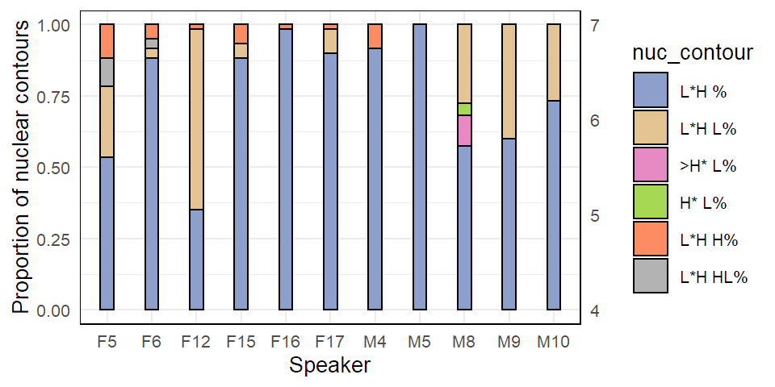

Distibution by mode of nuclear contours in M-corpus (adjusted)

| mode | L*H % | L*H L% | L*H H% | L*H HL% | >H* L% | H* L% |
| --- | --- | --- | --- | --- | --- | --- |
| MDC | 139 | 17 | 0 | 0 | 2 | 2 |
| MWH | 148 | 17 | 0 | 0 | 0 | 0 |
| MYN | 124 | 29 | 5 | 0 | 2 | 0 |
| MDQ | 82 | 54 | 17 | 8 | 1 | 0 |
| Total | 493 | 117 | 22 | 8 | 5 | 2 |

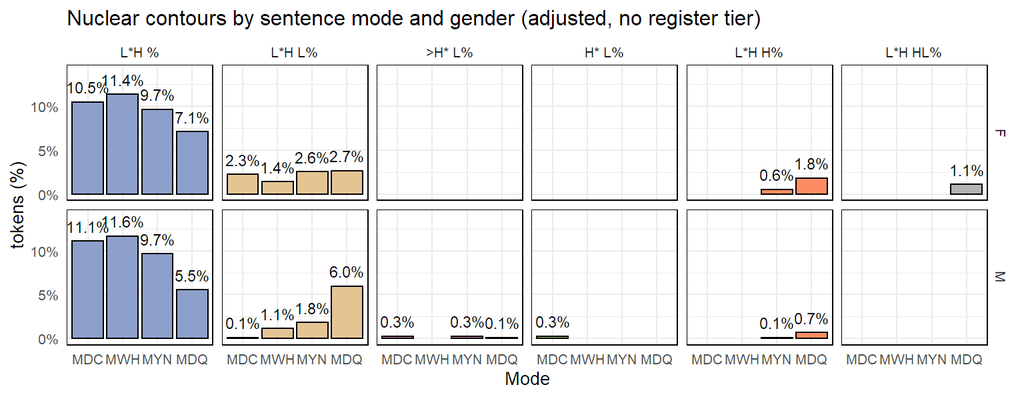

It appears that the male speakers are more likely to begin using L% across the question mode hierarchy more than the female speakers. There are not enough speakers, I believe, however, to justify this as a general conclusion, especially as it is only M8, M9, and M10 who do this.

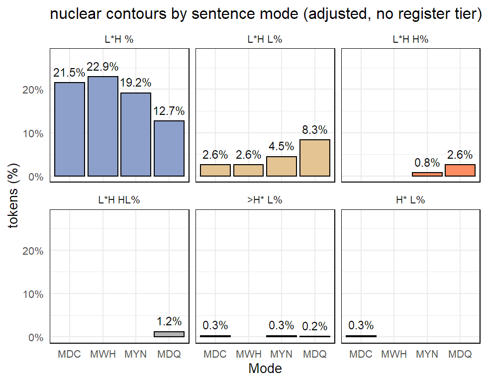

The overall pattern suggest that L% is more common among YNQs and and DCQs. However, I don’t think that the L% is used to signal a question. I think that, as with the A&H corpus, L% is used when the speaker indicates there is a conflict of expectation of shared knowledge between the speaker and listener. Thus in questions like “You live in the valley?” and “Do you live in the valley?”, speaker can use the L% to indicate that the propositional content conflicts with what he or she had previously believed; i.e., it indicates surprise. In a reciprocal manner, in the declaratives of the A&H corpus (and here), the use of an L% indicates that the speaker is indicating surprise that the listener does not already share the knowledge. (i.e. “Where do you live?…”I live in the valley [L%] (and I assumed you already knew that / and you should know that already.”) … Perhaps the best way to think of this is as the surprise~redundancy strategy, with the conflict of expectations expressing redundancy in the declaratives (“This should not be news to you.”) and surprise in the questions (“I did not know this at all!”).

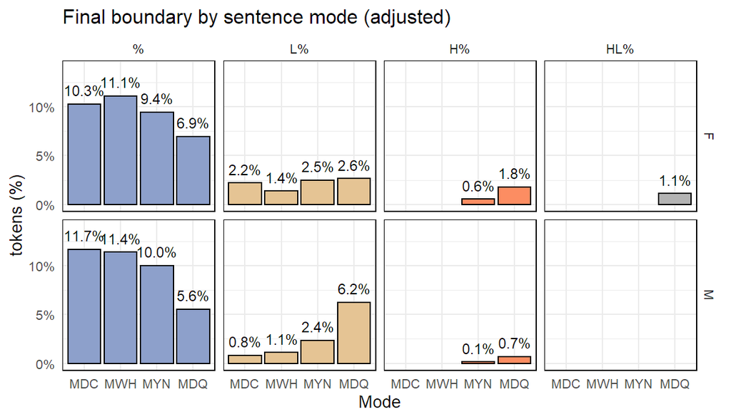

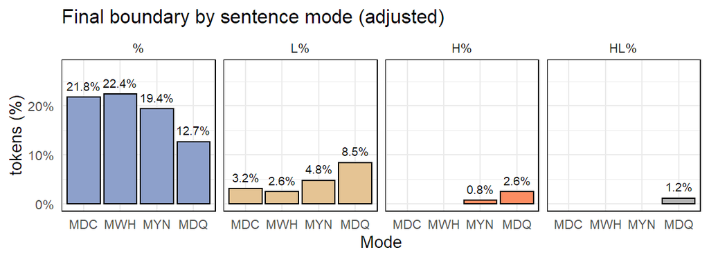

The results give the impression that this is a feature of male rather than female speech. However, only three out of the five male speakers do this, so it is unlikely to be a features of “male speech”. More likely, different speakers interpreted the motivation behind the prompt statement and their response, in terms of the intonational phonology, reflects whether or not they chose to use a surprise/redundancy falling boundary.

#### GLMM test of fin_phon H as a fn of mode.

- **Complete separation issue**
- GLMER cannot correctly estimate the CIs of H:L for MDC and MWH since there are no instances of H for either level, leading to a problem know as “complete separation”. (The odds ratio for L is 1:0 against and for H it is 0:1 for, making the probability 0 but the CIs stretch from 0 to infinity.)

To resolve this issue, I have used the blme package, which uses “Maximum a posteriori estimation for linear and generalized linear mixed-effects models in a Bayesian setting” (documentation).

(http://bbolker.github.io/mixedmodels-misc/ecostats_chap.html#digression-complete-separation)

(directed from https://bbolker.github.io/mixedmodels-misc/glmmFAQ.html#penalizationhandling-complete-separation)

#### **GLMM analysis for H% tier**

```
## Cov prior  : speaker ~ wishart(df = 3.5, scale = Inf, posterior.scale = cov, common.scale = TRUE)
##            : prompt ~ wishart(df = 3.5, scale = Inf, posterior.scale = cov, common.scale = TRUE)
## Fixef prior: normal(sd = c(10, 2.5, ...), corr = c(0 ...), common.scale = FALSE)
## Prior dev  : 24.292
##
## Generalized linear mixed model fit by maximum likelihood (Laplace
##   Approximation) [bglmerMod]
##  Family: binomial  ( logit )
## Formula: is_H_boundary ~ mode + gender + (1 | speaker) + (1 | prompt)
##    Data: m_corpus_is_H_boundary
##
##      AIC      BIC   logLik deviance df.resid
##    164.2    195.4    -75.1    150.2      632
##
## Scaled residuals:
##     Min      1Q  Median      3Q     Max
## -1.4111 -0.1227 -0.0412 -0.0180  4.7219
##
## Random effects:
##  Groups  Name        Variance Std.Dev.
##  speaker (Intercept) 3.7151   1.9275
##  prompt  (Intercept) 0.7351   0.8574
## Number of obs: 639, groups:  speaker, 11; prompt, 3
##
## Fixed effects:
##             Estimate Std. Error z value Pr(>|z|)
## (Intercept)  -6.0926     1.3393  -4.549 5.38e-06 ***
## modeMWH      -1.3491     1.7157  -0.786   0.4317
## modeMYN       1.9289     1.0007   1.928   0.0539 .
## modeMDQ       4.1480     0.9513   4.360 1.30e-05 ***
## genderM      -2.0365     1.2923  -1.576   0.1150
## ---
## Signif. codes:  0 '***' 0.001 '**' 0.01 '*' 0.05 '.' 0.1 ' ' 1
##
## Correlation of Fixed Effects:
##         (Intr) modMWH modMYN modMDQ
## modeMWH -0.201
## modeMYN -0.592  0.265
## modeMDQ -0.676  0.284  0.830
## genderM -0.257  0.000 -0.006 -0.023
```

isSingular(fin_phon_model_H_or_not, tol=1e-5) –> FALSE

ANOVA of model and null model, assuming no register tier.

|  | npar | AIC | BIC | logLik | deviance | Chisq | Df | Pr(>Chisq) |
| --- | --- | --- | --- | --- | --- | --- | --- | --- |
| fin_phon_model_H_or_not_null | 3 | 224.9419 | 238.3216 | -109.47093 | 218.9419 | NA | NA | NA |
| fin_phon_model_H_or_not | 7 | 164.1882 | 195.4075 | -75.09408 | 150.1882 | 68.7537 | 4 | 4.159525e-14 |

Conditional and marginal R<sup>2</sup> of model

| R2_conditional | R2_marginal |
| --- | --- |
| 0.75 | 0.41 |

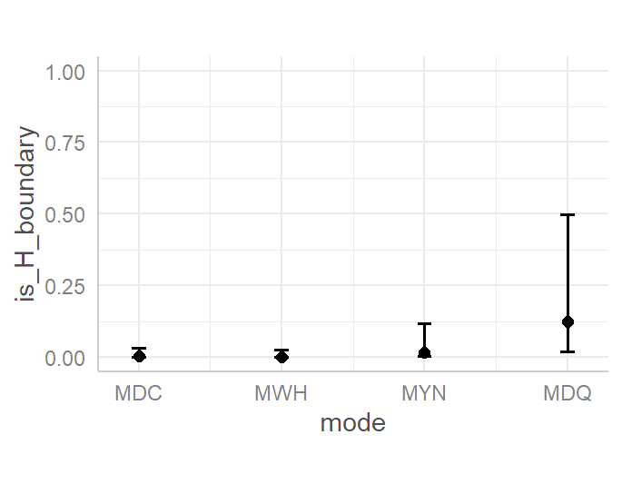

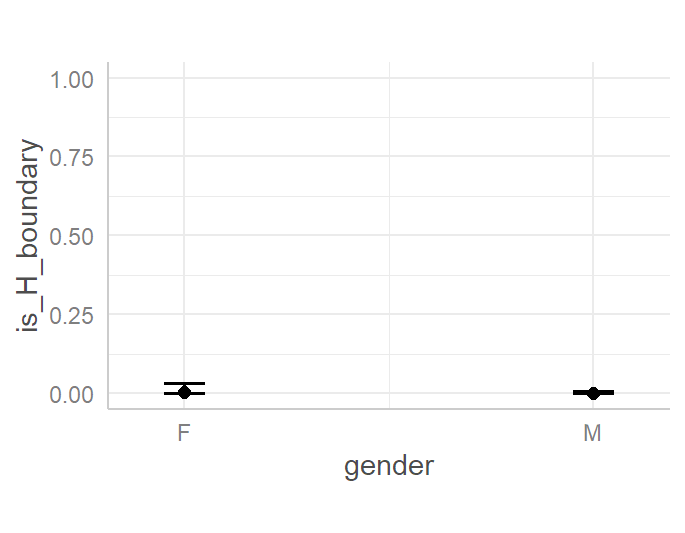

Conditional and marginal R<sup>2</sup> of model

| R2_conditional | R2_marginal |
| --- | --- |
| 0.75 | 0.41 |

summary of model: is_H_boundary ~ mode + gender + (1 | speaker) + (1 | prompt)

| term | estimate | conf.low | conf.high | std.error | z.value | p.value |
| --- | --- | --- | --- | --- | --- | --- |
| (Intercept) | -6.093 | -8.718 | -3.468 | 1.339 | -4.549 | 5.4e-06 |
| modeMWH | -1.349 | -4.712 | 2.014 | 1.716 | -0.786 | 0.4317 |
| modeMYN | 1.929 | -0.032 | 3.89 | 1.001 | 1.928 | 0.0539 |
| modeMDQ | 4.148 | 2.283 | 6.012 | 0.951 | 4.360 | 1.3e-05 |
| genderM | -2.037 | -4.569 | 0.496 | 1.292 | -1.576 | 0.115 |

b0 for is_H_boundary ~ mode + gender + (1 | speaker) + (1 | prompt)

| intercept | estimate | conf.low | conf.high | std.error | z.value | p.value |
| --- | --- | --- | --- | --- | --- | --- |
| modeMDC | -6.093 | -9.083 | -3.102 | 1.526 | -3.993 | 6.5e-05 |
| modeMWH | -6.091 | -9.083 | -3.099 | 1.527 | -3.990 | 6.6e-05 |
| modeMYN | -4.228 | -6.391 | -2.064 | 1.104 | -3.830 | 1.3e-04 |
| modeMDQ | -2.027 | -3.93 | -0.124 | 0.971 | -2.088 | 0.037 |

b1 for is_H_boundary ~ mode + gender + (1 | speaker) + (1 | prompt)

| intercept | slope | estimate | conf.low | conf.high | std.error | z.value | p.value |
| --- | --- | --- | --- | --- | --- | --- | --- |
| modeMDC | modeMWH | -1.349 | -6.35 | 3.652 | 2.552 | -0.529 | 0.597 |
| modeMDC | modeMYN | 1.929 | -0.573 | 4.43 | 1.276 | 1.511 | 0.131 |
| modeMDC | modeMDQ | 4.148 | 1.771 | 6.525 | 1.213 | 3.420 | 6.3e-04 |
| modeMWH | modeMYN | 1.927 | -0.575 | 4.43 | 1.277 | 1.509 | 0.131 |
| modeMWH | modeMDQ | 4.146 | 1.767 | 6.525 | 1.214 | 3.416 | 6.4e-04 |
| modeMYN | modeMDQ | 2.278 | 1.12 | 3.436 | 0.591 | 3.855 | 1.2e-04 |
| intercept | genderM | -2.037 | -4.971 | 0.898 | 1.497 | -1.360 | 0.174 |

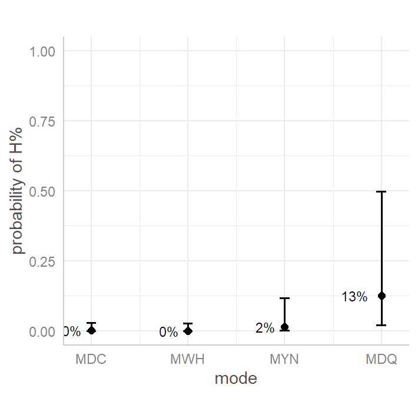